# Lab 7: Multiple Linear Regression

Author

Yinjiao Zhong

Published

March 26, 2024

## 0.1 Lab Setup

Set my working directory and load libraries.

```r
library(car)
library(relaimpo)
library(lmtest)
library(stargazer)
# get lab data
yield <- read.csv('yielddata.csv')
head(yield)
```

```
          State   District    Yield Canal_Dist Irrigated_Per  Literate
1 Uttar Pradesh      Unnao 2965.788  8.6252015     1.0000000 0.1739130
2 Uttar Pradesh   Fatehpur 3248.265  2.5355166     1.0000000 0.4814490
3         Bihar Aurangabad 2538.736  0.7909722     0.4166492 0.4355878
4 Uttar Pradesh   Ghazipur 3173.908  7.4172259     0.6296039 0.4564417
5 Uttar Pradesh      Kheri 2961.298  0.9256326     1.0000000 0.5017544
6 Uttar Pradesh  Kaushambi 3087.786 13.8004294     0.6902360 0.2195270
  Cultivator    AgLabor     Rain Temperature Elevation  SowDate
1 0.25585284 0.01170569 223.8928    12.81596       116 4.738676
2 0.08881098 0.05316973 235.6471    12.54157       118 4.321697
3 0.08856683 0.08776167 309.5277    14.09054       112 4.117498
4 0.08036810 0.04171779 314.6497    13.92136        72 3.293600
5 0.16140351 0.08947368 310.8220    11.64079       152 6.461493
6 0.08671922 0.02850212 255.1154    12.97836       105 4.751297
```

# 1 Exercise 1

## 1.1 Question 1.1

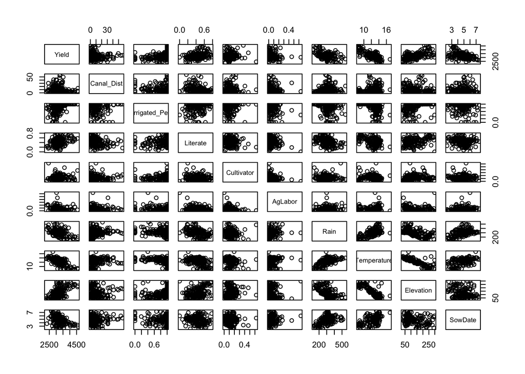

```r
# get scatter plot
pairs(yield[,3:12])
```

```r
# get correlation of the continuous variables
cor(yield[,3:12], use='complete.obs')
```

```
                    Yield   Canal_Dist Irrigated_Per   Literate  Cultivator
Yield          1.00000000 -0.100792366    0.37291308  0.3457707  0.02234091
Canal_Dist    -0.10079237  1.000000000   -0.07972347 -0.2496504  0.06540877
Irrigated_Per  0.37291308 -0.079723466    1.00000000  0.2509635  0.05162662
Literate       0.34577067 -0.249650351    0.25096345  1.0000000 -0.13693696
Cultivator     0.02234091  0.065408774    0.05162662 -0.1369370  1.00000000
AgLabor       -0.15816302 -0.001745039   -0.21556017 -0.1769701 -0.26558944
Rain          -0.46098180  0.132098845   -0.23158320 -0.3669876 -0.05561866
Temperature   -0.69818335  0.079179775   -0.42512905 -0.3725307 -0.14538940
Elevation      0.57367350 -0.044009816    0.36640038  0.3117005  0.11161674
SowDate       -0.44594054  0.055231777   -0.08520842 -0.1669194 -0.05514825
                   AgLabor        Rain Temperature   Elevation     SowDate
Yield         -0.158163024 -0.46098180 -0.69818335  0.57367350 -0.44594054
Canal_Dist    -0.001745039  0.13209885  0.07917977 -0.04400982  0.05523178
Irrigated_Per -0.215560168 -0.23158320 -0.42512905  0.36640038 -0.08520842
Literate      -0.176970123 -0.36698760 -0.37253074  0.31170047 -0.16691936
Cultivator    -0.265589442 -0.05561866 -0.14538940  0.11161674 -0.05514825
AgLabor        1.000000000  0.09390849  0.09030555  0.01043637  0.11992541
Rain           0.093908491  1.00000000  0.62937563 -0.56896820  0.46630992
Temperature    0.090305550  0.62937563  1.00000000 -0.87606076  0.46552392
Elevation      0.010436371 -0.56896820 -0.87606076  1.00000000 -0.31366412
SowDate        0.119925409  0.46630992  0.46552392 -0.31366412  1.00000000
```

```r
# get VIF
vif(lm(data=yield, Yield~Canal_Dist+Irrigated_Per+Literate+Cultivator+AgLabor+Rain+Temperature+Elevation+SowDate))
```

```
   Canal_Dist Irrigated_Per      Literate    Cultivator       AgLabor
     1.079929      1.320238      1.392133      1.178451      1.231330
         Rain   Temperature     Elevation       SowDate
     1.874005      6.081935      4.742333      1.490840
```

**Answer**:

-From this scatter plot result, we could get some information about correlation of the continuous variables, such as Temperature and Elevation has strong negative correlation.

-As the correlation matrix shows, the correlation between Temperature and Elevation is 0.876, which is highest here. And the correlation between Temperature and Rain is 0.629.

-Then, we could know the VIF of Temperature is high, which is 6.082 bigger than 5 and means Temperature is highly correlated with other variables. So, in my model, Temperature leads to multi-collinearity; In addition, Elevation’s VIF is 4.742, which is close to 5, which may also cause my model to appear multi-collinearity.

## 1.2 Question 1.2

According to the result of correlation, we could know Temperature and Elevation are the most correlated variables.

```r
# get the univariate models of this two variables
univarmod1 <- lm(Yield~Temperature, data=yield)
univarmod2 <- lm(Yield~Elevation, data=yield)

# get the multivariate model of this two variables
multivarmod <- lm(Yield~Temperature+Elevation, data=yield)

summary(univarmod1)
```

```
Call:
lm(formula = Yield ~ Temperature, data = yield)

Residuals:
    Min      1Q  Median      3Q     Max
-775.96 -191.99    5.34  202.63  733.14

Coefficients:
            Estimate Std. Error t value Pr(>|t|)
(Intercept)  5531.24     168.46   32.83   <2e-16 ***
Temperature  -186.43      13.38  -13.94   <2e-16 ***
---
Signif. codes:  0 '***' 0.001 '**' 0.01 '*' 0.05 '.' 0.1 ' ' 1

Residual standard error: 290.9 on 198 degrees of freedom
Multiple R-squared:  0.4951,    Adjusted R-squared:  0.4926
F-statistic: 194.2 on 1 and 198 DF,  p-value: < 2.2e-16
```

```r
summary(univarmod2)
```

```
Call:
lm(formula = Yield ~ Elevation, data = yield)

Residuals:
   Min     1Q Median     3Q    Max
-804.6 -225.0   -6.9  195.9 1063.1

Coefficients:
             Estimate Std. Error t value Pr(>|t|)
(Intercept) 2779.1943    50.2639  55.292   <2e-16 ***
Elevation      3.4208     0.3582   9.551   <2e-16 ***
---
Signif. codes:  0 '***' 0.001 '**' 0.01 '*' 0.05 '.' 0.1 ' ' 1

Residual standard error: 338.7 on 198 degrees of freedom
Multiple R-squared:  0.3154,    Adjusted R-squared:  0.3119
F-statistic: 91.22 on 1 and 198 DF,  p-value: < 2.2e-16
```

```r
summary(multivarmod)
```

```
Call:
lm(formula = Yield ~ Temperature + Elevation, data = yield)

Residuals:
    Min      1Q  Median      3Q     Max
-786.95 -189.79    4.24  204.59  712.88

Coefficients:
             Estimate Std. Error t value Pr(>|t|)
(Intercept) 5864.7319   367.2957  15.967  < 2e-16 ***
Temperature -207.4310    24.5211  -8.459 6.02e-15 ***
Elevation     -0.5760     0.5638  -1.022    0.308
---
Signif. codes:  0 '***' 0.001 '**' 0.01 '*' 0.05 '.' 0.1 ' ' 1

Residual standard error: 290.8 on 197 degrees of freedom
Multiple R-squared:  0.4978,    Adjusted R-squared:  0.4927
F-statistic: 97.64 on 2 and 197 DF,  p-value: < 2.2e-16
```

**Answer**:

-As a result, the model may assign some of the effects of one variable to another, making estimates of the coefficients unstable. This is why beta is different from univariate and multivariate models.

# 2 Exercise 2

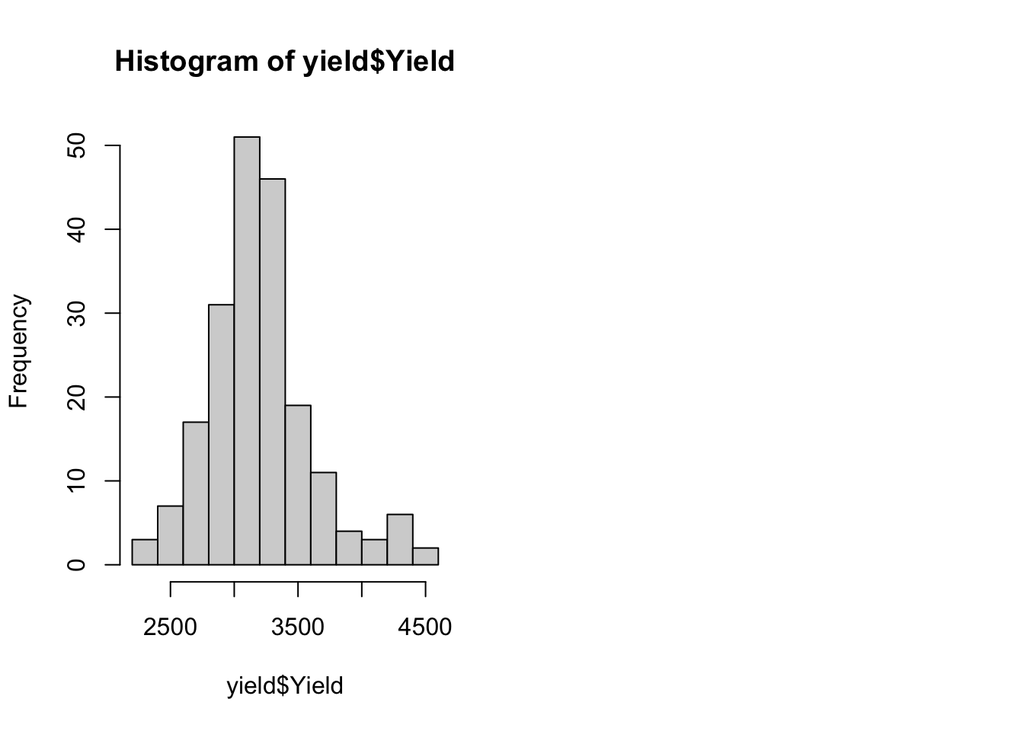

```r
par(mfrow = c(1,2))
hist(yield$Yield)
```

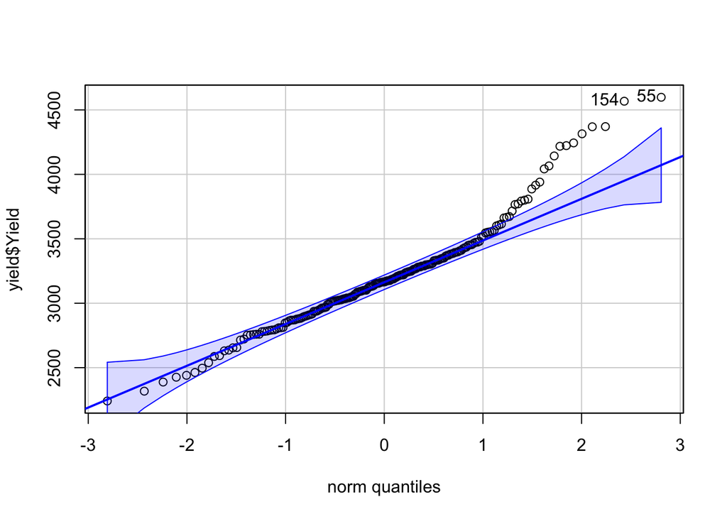

```
[1]  55 154
```

```r
qqPlot(yield$Yield)
```

## 2.1 Question 2.1

```r
fullmod2 <- lm(Yield ~ Canal_Dist + Irrigated_Per + Literate + Cultivator + AgLabor + Temperature + SowDate, data = yield)
smallmod <- lm(Yield ~ Canal_Dist + Irrigated_Per + Temperature + SowDate, data = yield)

# get the AIC
AIC(fullmod2)
```

```
[1] 2275.772
```

```r
AIC(smallmod)
```

```
[1] 2477.5
```

**Answer**:

According to the AIC of this two models, the full model has the smaller AIC. So, I would choose the full model.

## 2.2 Question 2.2

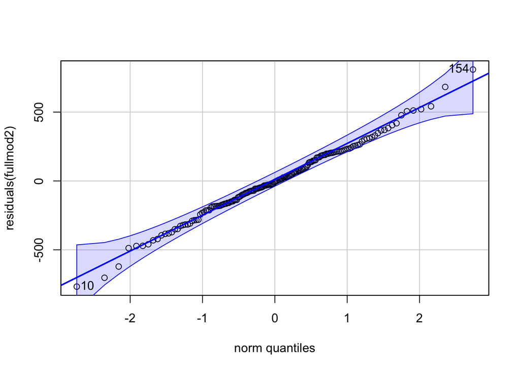

```
154  10
132  10
```

```r
## check the assumption of normality
# run Q-Q plot
qqPlot(residuals(fullmod2))
```

```r
# use Shapiro-Wilk test
shapiro.test(residuals(fullmod2))
```

```
    Shapiro-Wilk normality test

data:  residuals(fullmod2)
W = 0.99425, p-value = 0.7778
```

**Answer**:

From the result of Q-Q plot, we could know the residuals are normally distributed. Then, according to the Shapiro-Wilk test, we can get the P-value is 0.778 > alpha = 0.05, so we can not reject null hypothesis: the residuals are normally distributed. Therefore, the requirement of residual normality is satisfied.

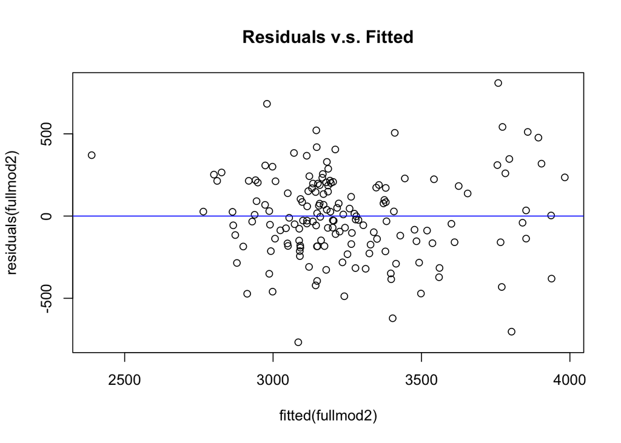

```r
## check the assumption of homoscedasticity
plot(residuals(fullmod2)~fitted(fullmod2), main='Residuals v.s. Fitted')
abline(h=0, col='blue')
```

```r
# statistical tests
bptest(fullmod2)
```

```
    studentized Breusch-Pagan test

data:  fullmod2
BP = 19.046, df = 7, p-value = 0.008045
```

```r
ncvTest(fullmod2)
```

```
Non-constant Variance Score Test
Variance formula: ~ fitted.values
Chisquare = 8.052352, Df = 1, p = 0.0045445
```

## 2.3 Question 2.3

```r
summary(fullmod2)
```

```
Call:
lm(formula = Yield ~ Canal_Dist + Irrigated_Per + Literate +
    Cultivator + AgLabor + Temperature + SowDate, data = yield)

Residuals:
    Min      1Q  Median      3Q     Max
-767.29 -163.64   -7.71  187.66  808.98

Coefficients:
               Estimate Std. Error t value Pr(>|t|)
(Intercept)   5194.7420   287.2336  18.085  < 2e-16 ***
Canal_Dist      -0.7176     1.9378  -0.370   0.7117
Irrigated_Per  132.1409    94.3785   1.400   0.1635
Literate       131.4272   159.7811   0.823   0.4120
Cultivator    -382.0980   261.5528  -1.461   0.1461
AgLabor       -390.2264   284.9760  -1.369   0.1729
Temperature   -142.9815    18.4862  -7.734 1.27e-12 ***
SowDate        -54.7208    22.0343  -2.483   0.0141 *
---
Signif. codes:  0 '***' 0.001 '**' 0.01 '*' 0.05 '.' 0.1 ' ' 1

Residual standard error: 263.7 on 154 degrees of freedom
  (38 observations deleted due to missingness)
Multiple R-squared:  0.5335,    Adjusted R-squared:  0.5123
F-statistic: 25.16 on 7 and 154 DF,  p-value: < 2.2e-16
```

```r
summary(univarmod1)
```

```
Call:
lm(formula = Yield ~ Temperature, data = yield)

Residuals:
    Min      1Q  Median      3Q     Max
-775.96 -191.99    5.34  202.63  733.14

Coefficients:
            Estimate Std. Error t value Pr(>|t|)
(Intercept)  5531.24     168.46   32.83   <2e-16 ***
Temperature  -186.43      13.38  -13.94   <2e-16 ***
---
Signif. codes:  0 '***' 0.001 '**' 0.01 '*' 0.05 '.' 0.1 ' ' 1

Residual standard error: 290.9 on 198 degrees of freedom
Multiple R-squared:  0.4951,    Adjusted R-squared:  0.4926
F-statistic: 194.2 on 1 and 198 DF,  p-value: < 2.2e-16
```

**Answer**:

-From the summary of the full model, the intercept(P-value = 2e-16 << alpha = 0.05), Temperature(P-value = 1.27e-12 << alpha = 0.05), and SowDate(P-value = 0.0141 < alpha = 0.05) are significant. The absolute value of the Temperature beta coefficient of the multivariate model (|-142.9815|) is smaller than that of the univariate model (|-186.4|).

-This is because the effect of temperature on yield in a multivariate model will be smaller than that in a univariate model that only considers temperature, compared to other dependent variables.

# 3 Exercise 3

## 3.1 Question 3.1

```r
calc.relimp(fullmod2, type=c('lmg'), rela=TRUE)
```

```
Response variable: Yield
Total response variance: 142570.8
Analysis based on 162 observations

7 Regressors:
Canal_Dist Irrigated_Per Literate Cultivator AgLabor Temperature SowDate
Proportion of variance explained by model: 53.35%
Metrics are normalized to sum to 100% (rela=TRUE).

Relative importance metrics:

                      lmg
Canal_Dist    0.005832744
Irrigated_Per 0.110412608
Literate      0.084733336
Cultivator    0.007104318
AgLabor       0.018953436
Temperature   0.591199084
SowDate       0.181764474

Average coefficients for different model sizes:

                       1X         2Xs         3Xs         4Xs          5Xs
Canal_Dist      -3.427562   -2.340213   -1.597039   -1.117275   -0.8397152
Irrigated_Per  556.986053  455.777540  370.378228  297.956931  235.6872750
Literate       862.918239  695.948341  550.924834  424.252770  313.1735417
Cultivator      97.798573   -0.815368  -83.147846 -159.357463 -234.3022470
AgLabor       -747.886598 -556.319902 -429.005304 -358.191022 -334.7664982
Temperature   -174.759453 -168.546054 -162.676162 -157.192254 -152.1052297
SowDate       -154.990658 -132.762298 -113.645195  -96.906542  -81.8602301
                       6Xs          7Xs
Canal_Dist      -0.7189361   -0.7175693
Irrigated_Per  181.0831753  132.1408988
Literate       215.8556081  131.4272404
Cultivator    -309.0948762 -382.0979838
AgLabor       -348.8859001 -390.2263964
Temperature   -147.3890286 -142.9814881
SowDate        -67.9402374  -54.7208073
```

**Answer**:

Based on the relative importance metrics, Temperature explains the most variance (0.59), SowDate explains the second most, and Canal_Dist(0.006) explains the least variance.